# Data processing of free-ranging dog movement

Mudumalai Tiger Reserve, India

Nilanjan Chatterjee

09 September, 2025

## Preamble

Load libraries

```r
library(amt)
library(tidyverse)
library(here)
library(terra)
library(readxl)
library(sf)
library(mapview)
library(geosphere)
library(ggspatial)
```

## Read the data

We are reading the raw dog movement data housed at Movebank to see if the outliers flagged by movebank are correct or not

```r
raw_data <- read.csv(here("Telemetry data", "Free-ranging dogs - vksanj - Mudumalai TR - GPS collaring.csv"))
raw_data$timestamp <-as.POSIXct(raw_data$timestamp, format = "%Y-%m-%d %H:%M:%OS",
                               tz = "Asia/Calcutta")
glimpse(raw_data)
```

```
## Rows: 27,850
## Columns: 13
## $ event.id                        <dbl> 37385141577, 37385141579, 37385141581,…
## $ visible                         <chr> "true", "true", "true", "true", "true"…
## $ timestamp                       <dttm> 2024-10-03 01:36:00, 2024-10-03 01:40…
## $ location.long                   <dbl> 76.63964, 76.63953, 76.63959, 76.63944…
## $ location.lat                    <dbl> 11.57584, 11.57584, 11.57575, 11.57486…
## $ algorithm.marked.outlier        <chr> "", "", "", "", "", "", "", "", "", ""…
## $ gps.hdop                        <dbl> 0.76, 1.19, 1.46, 1.15, 1.41, 1.41, 0.…
## $ manually.marked.outlier         <chr> "", "", "", "", "", "", "", "", "", ""…
## $ sensor.type                     <chr> "gps", "gps", "gps", "gps", "gps", "gp…
## $ individual.taxon.canonical.name <chr> "Canidae", "Canidae", "Canidae", "Cani…
## $ tag.local.identifier            <int> 10340, 10340, 10340, 10340, 10340, 103…
## $ individual.local.identifier     <chr> "Pied", "Pied", "Pied", "Pied", "Pied"…
## $ study.name                      <chr> "Free-ranging dogs - vksanj - Mudumala…
```

```r
summary(raw_data)
```

```
##     event.id           visible            timestamp
##  Min.   :3.739e+10   Length:27850       Min.   :2024-09-23 10:08:00.0
##  1st Qu.:3.739e+10   Class :character   1st Qu.:2024-10-11 21:07:00.0
##  Median :3.739e+10   Mode  :character   Median :2024-10-19 12:03:30.0
##  Mean   :3.739e+10                      Mean   :2024-10-18 18:37:30.2
##  3rd Qu.:3.739e+10                      3rd Qu.:2024-10-25 08:56:00.0
##  Max.   :3.739e+10                      Max.   :2024-11-10 08:51:00.0
##
##  location.long    location.lat   algorithm.marked.outlier    gps.hdop
##  Min.   :76.41   Min.   :11.47   Length:27850             Min.   : 0.000
##  1st Qu.:76.64   1st Qu.:11.57   Class :character         1st Qu.: 1.200
##  Median :76.69   Median :11.60   Mode  :character         Median : 1.540
##  Mean   :76.67   Mean   :11.59                            Mean   : 1.738
##  3rd Qu.:76.69   3rd Qu.:11.60                            3rd Qu.: 2.060
##  Max.   :76.71   Max.   :11.67                            Max.   :99.990
##  NA's   :4146    NA's   :4146
##  manually.marked.outlier sensor.type        individual.taxon.canonical.name
##  Length:27850            Length:27850       Length:27850
##  Class :character        Class :character   Class :character
##  Mode  :character        Mode  :character   Mode  :character
##
##
##
##
##  tag.local.identifier individual.local.identifier  study.name
##  Min.   :10340        Length:27850                Length:27850
##  1st Qu.:10343        Class :character            Class :character
##  Median :10373        Mode  :character            Mode  :character
##  Mean   :10362
##  3rd Qu.:10374
##  Max.   :10376
##
```

## Data processing

We want to do basic processing of the data (NA removal, HDOP and speed filtering) We are also converting the data into spatial format and plot them simultaneously to check for the speed and manually marked outliers.

- 4146 points are dropped because of NA location *i.e.* when the collar could not communicate successfully with the satellite.
- 4 points were dropped as they were imprecise (HDOP >10 m).
- The remaining points were processed in the next step through visualization.

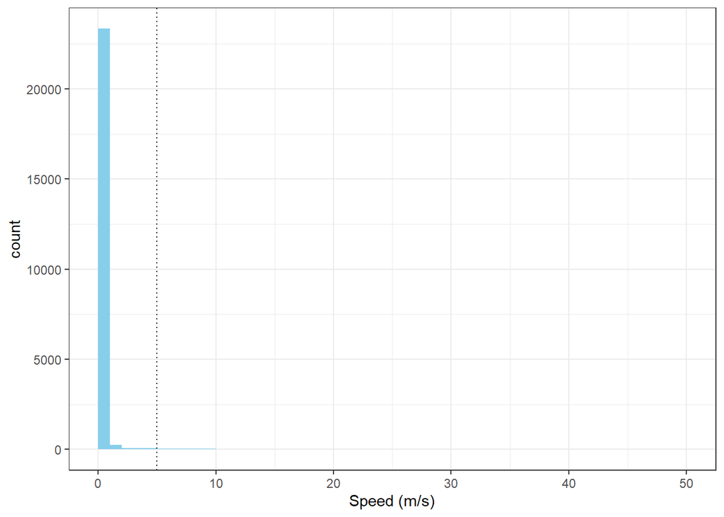

```r
data_df <- raw_data |>
  drop_na(location.long) |>
  filter(gps.hdop <10) |>
  group_by(individual.local.identifier) |>
  arrange(timestamp) |>
  mutate(
  step_length = distHaversine(cbind(location.long, location.lat),
                              cbind(lag(location.long), lag(location.lat))),  # in meters
  time_diff = as.numeric(difftime(timestamp, lag(timestamp), units = "secs")),
  speed_mps = step_length / time_diff)|>
  ungroup()
data_df$speed_mps[is.na(data_df$speed_mps)]<-0

ggplot(data_df)+
  geom_histogram(aes(x = speed_mps), fill = "skyblue", breaks = c(0, 1,2, 5,10,25,50))+
  geom_vline(xintercept = 5, linetype=3)+
  labs(x = "Speed (m/s)")+
  theme_bw()
```

```r
data_sf <- data_df |>
  st_as_sf(coords = c("location.long", "location.lat"), crs = 4326)
```

## Data visualization

Here we are visualizing all the individual dog tracks to see if there are any outliers and how the points marked with outliers are marked correctly The green points are marked as outlier by the speed filter of 5 m/s.

```
## Zoom: 10
```

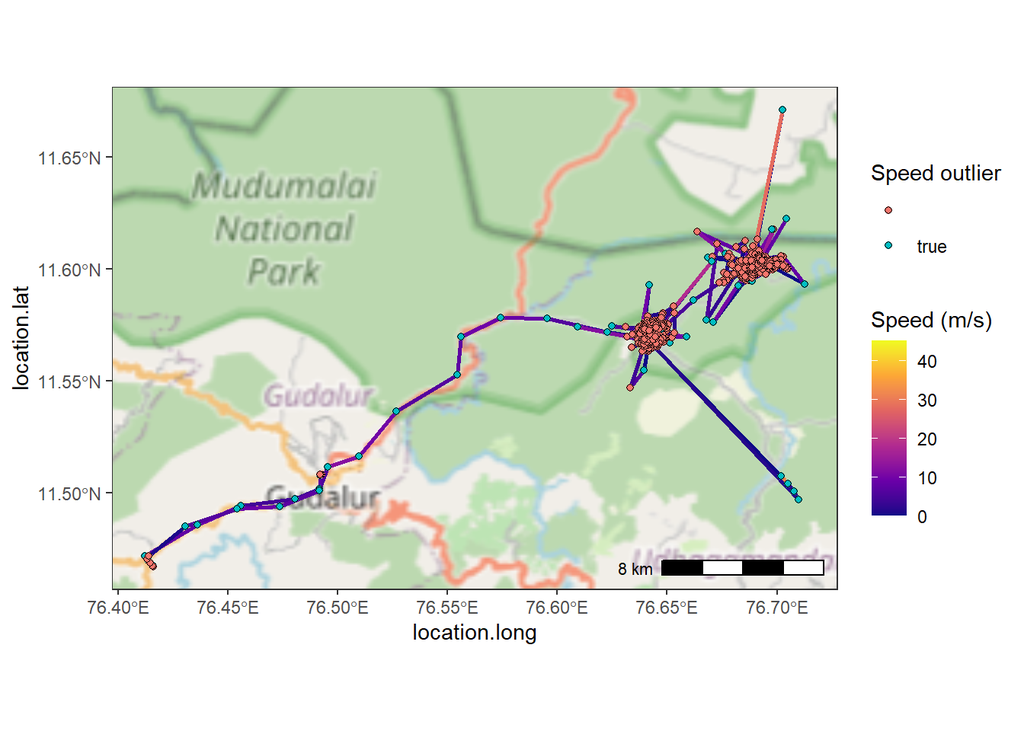

```r
data_track <- data_sf |>
  group_by(individual.local.identifier) |>
  summarise(do_union = FALSE) |>
  st_cast("LINESTRING")

ggplot()+
  geom_sf(data = data_track)+
  annotation_map_tile(type = "osm") +
  geom_path(data = data_df, aes(x = location.long, y = location.lat, col = speed_mps,
                                group= individual.local.identifier), linewidth=1)+
  scale_color_viridis_c(option = "plasma")+
  geom_sf(data = data_sf, aes(fill = algorithm.marked.outlier), shape=21)+
  annotation_scale(location = "br")+
  labs(fill = "Speed outlier", col = "Speed (m/s)")+
  theme_bw()
```

We can clearly see some outliers from the animal track and the histogram plot of speed We drop the locations and plot again to see how the tracks look like. The plot histogram looks much better and represents a distribution pattern that ecologically looks much better compared to the previous histogram.

```r
data_df <- data_df |> filter(speed_mps < 5) |>
  filter(location.long> 76.6 & location.lat > 11.52)
data_df$manually.marked.outlier[data_df$manually.marked.outlier==""]<- "false"
glimpse(data_df)
```

```
## Rows: 23,630
## Columns: 16
## $ event.id                        <dbl> 37385138326, 37385138327, 37385138328,…
## $ visible                         <chr> "true", "true", "true", "true", "true"…
## $ timestamp                       <dttm> 2024-09-23 10:08:00, 2024-09-23 10:13…
## $ location.long                   <dbl> 76.64213, 76.64180, 76.64148, 76.63924…
## $ location.lat                    <dbl> 11.56756, 11.56772, 11.56791, 11.56912…
## $ algorithm.marked.outlier        <chr> "", "", "", "", "", "", "", "", "", ""…
## $ gps.hdop                        <dbl> 1.41, 0.90, 1.11, 0.90, 0.85, 0.83, 1.…
## $ manually.marked.outlier         <chr> "false", "false", "false", "false", "f…
## $ sensor.type                     <chr> "gps", "gps", "gps", "gps", "gps", "gp…
## $ individual.taxon.canonical.name <chr> "Canidae", "Canidae", "Canidae", "Cani…
## $ tag.local.identifier            <int> 10376, 10376, 10376, 10376, 10376, 103…
## $ individual.local.identifier     <chr> "Mani", "Mani", "Mani", "Mani", "Mani"…
## $ study.name                      <chr> "Free-ranging dogs - vksanj - Mudumala…
## $ step_length                     <dbl> NA, 40.15551, 40.80772, 278.96388, 297…
## $ time_diff                       <dbl> NA, 300, 300, 300, 300, 300, 300, 300,…
## $ speed_mps                       <dbl> 0.00000000, 0.13385169, 0.13602574, 0.…
```

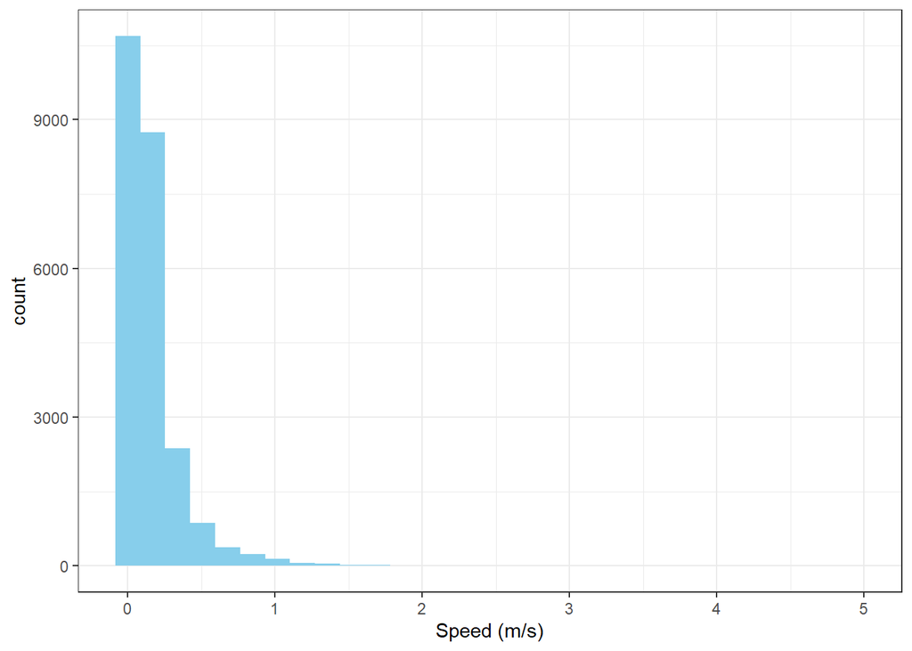

```r
ggplot(data_df)+
  geom_histogram(aes(x = speed_mps), fill = "skyblue")+
  labs(x = "Speed (m/s)")+
  theme_bw()
```

Convert the animal track again into sf format and check the plot for outliers. Now we want to see manually marked outliers to see how they are distributed.

```
## Zoom: 12
```

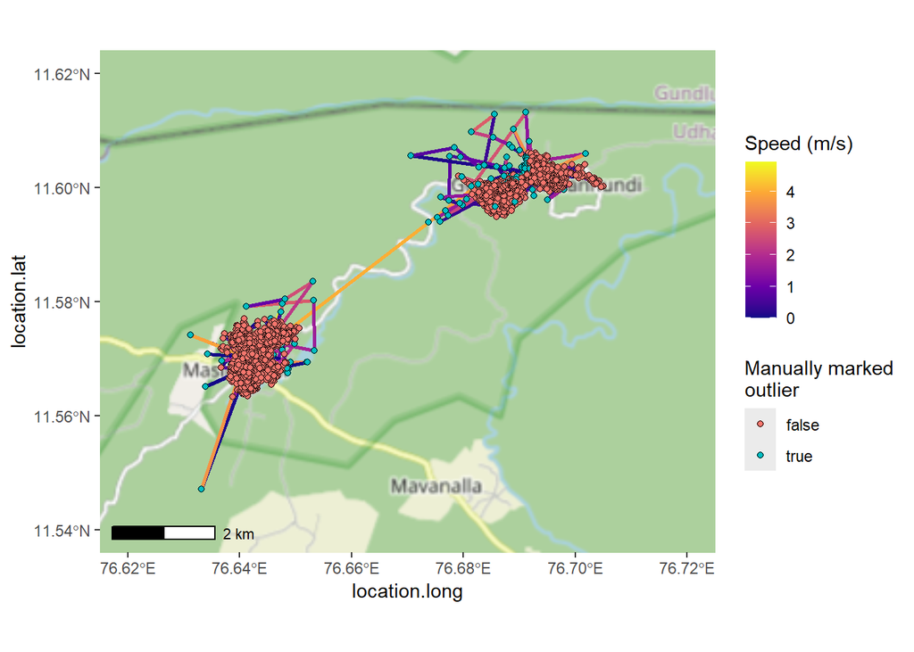

```r
data_sf <- data_df |>
  st_as_sf(coords = c("location.long", "location.lat"), crs = 4326)

ggplot()+
  geom_sf(data = data_track)+
  annotation_map_tile(type = "osm") +
  geom_path(data = data_df, aes(x = location.long, y = location.lat, col = speed_mps,
                                group= individual.local.identifier), linewidth = 1)+
  scale_color_viridis_c(option = "plasma")+
  geom_sf(data = data_sf, aes(fill = manually.marked.outlier), shape=21)+
  annotation_scale(location = "bl")+
  coord_sf(ylim = c(11.54, 11.62), xlim =  c(76.62, 76.72))+
  labs(fill = "Manually marked\noutlier", col = "Speed (m/s)")
```

In this step, we are plotting the sampling duration for each dogs to check how the temporal pattern look like In particular, we are looking for large gaps in the data that may bias our results.

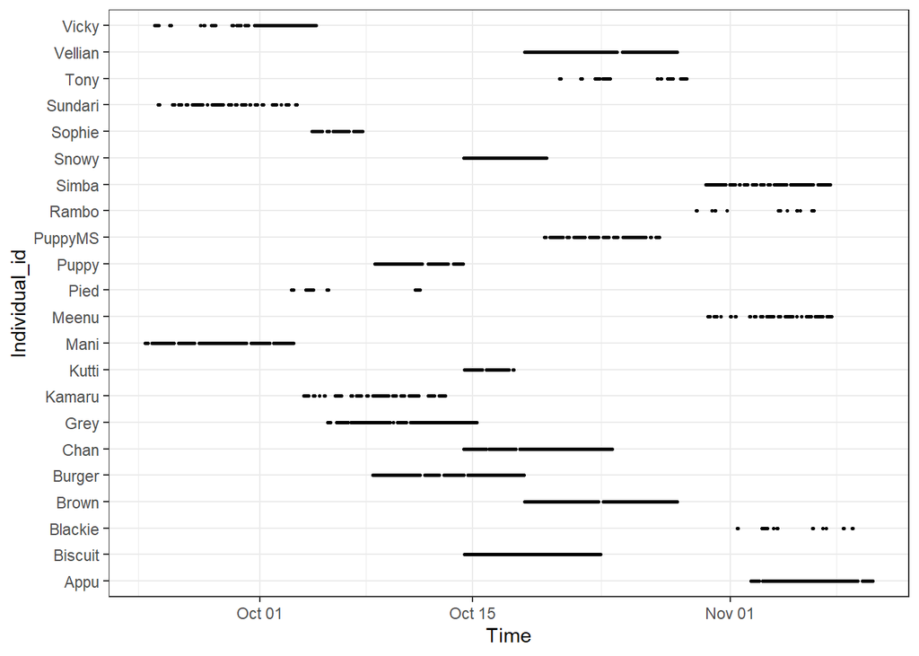

```r
ggplot(data_df) +
  geom_point(aes(x = timestamp, y = individual.local.identifier), size = 0.5) +
  labs(x= "Time", y= "Individual_id")+
  theme(legend.position = "none")+
  theme_bw()
```

#### Temporal summary analysis

We are creating an individual-wise *track* data from the movement data

```r
### create amt track data from the movement data
track_dat <- data_df %>%
  arrange(individual.local.identifier, timestamp) %>%
  mk_track(location.long, location.lat, timestamp,
           Name = individual.local.identifier,
           crs = 4326)  # CRS 4326 is the coordinate reference system

### I am looking for the fix interval rates across individual to see if there is
### any large gap in the data
mov_datsum <- track_dat %>% nest(data=-"Name") %>%
  mutate(data = map(data, ~ summarize_sampling_rate(.x, time_unit = "min"))) %>%
  dplyr::select(Name , data) %>%
  unnest(cols = data) %>% print(n =Inf)
```

```
## # A tibble: 22 × 10
##    Name      min    q1 median   mean    q3   max     sd     n unit
##  * <chr>   <dbl> <dbl>  <dbl>  <dbl> <dbl> <dbl>  <dbl> <int> <chr>
##  1 Mani        4     5      5   6.50     5   448  20.2   2175 min
##  2 Vicky       4     5      5  48.0     60  2796 196.     318 min
##  3 Sundari     4     5      5  20.3      5  1259  90.4    650 min
##  4 Pied        4     5      5  56.5      5  8254 573.     216 min
##  5 Kamaru      4     5      5  14.8      5   933  69.4    906 min
##  6 Sophie      4     5      5   7.72     5   429  29.2    622 min
##  7 Grey       59    60     61  81.8     61   602  63.7    173 min
##  8 Burger      4     5      5   6.61     5   461  16.7   2173 min
##  9 Puppy       4     5      5   6.91     5   597  23.4   1216 min
## 10 Snowy      59    60     60  61.1     60   119   7.32   129 min
## 11 Chan        4     5      5   7.46     5   422  14.9   1884 min
## 12 Biscuit     4     5      5   5.29     5    50   2.27  2449 min
## 13 Kutti       4     5      5   6.08     5   414  20.9    765 min
## 14 Brown       4     5      5   5.22     5   413   7.83  2783 min
## 15 Vellian     3     5      5   6.47     5   517  13.6   2247 min
## 16 PuppyMS     4     5      5   9.56     5   541  38.2   1139 min
## 17 Tony        4     5      5  39.3      5  4473 290.     307 min
## 18 Rambo       4     5      5 146.       5  4901 615.      76 min
## 19 Simba       4     5      5   7.85     5   413  31.5   1500 min
## 20 Meenu       4     5      5  18.2      6  1301  84.8    646 min
## 21 Blackie     4     5      5 166.       6  3329 544.      66 min
## 22 Appu        4     5      5   9.90    10   449  19.4   1168 min
```

We can see individuals like **Rambo**, **Tony**, **Blackie** and **Pied** do not have a lot of data and the data are very scattered across the sampling duration, which we do not want to use in the analysis further as the inference may not be robust.